# Modèle prédictif : Régression logistique

```
Dans cet article, j'aimerais réaliser une régression logistique sur une base de donnée provenant d'une banque.
```

```r
library(tidyverse)
```

```r
library(broom)
```

```r
bank <- read.csv("loan_data.csv")
```

```r
bank %>% head()
```

| credit.policy | purpose | int.rate | installment | log.annual.inc | dti | fico | days.with.cr.line | revol.bal | revol.util | inq.last.6mths | delinq.2yrs | pub.rec | not.fully.paid |
| --- | --- | --- | --- | --- | --- | --- | --- | --- | --- | --- | --- | --- | --- |
| 1 | debt_consolidation | 0.1189 | 829.10 | 11.35041 | 19.48 | 737 | 5639.958 | 28854 | 52.1 | 0 | 0 | 0 | 0 |
| 1 | credit_card | 0.1071 | 228.22 | 11.08214 | 14.29 | 707 | 2760.000 | 33623 | 76.7 | 0 | 0 | 0 | 0 |
| 1 | debt_consolidation | 0.1357 | 366.86 | 10.37349 | 11.63 | 682 | 4710.000 | 3511 | 25.6 | 1 | 0 | 0 | 0 |
| 1 | debt_consolidation | 0.1008 | 162.34 | 11.35041 | 8.10 | 712 | 2699.958 | 33667 | 73.2 | 1 | 0 | 0 | 0 |
| 1 | credit_card | 0.1426 | 102.92 | 11.29973 | 14.97 | 667 | 4066.000 | 4740 | 39.5 | 0 | 1 | 0 | 0 |
| 1 | credit_card | 0.0788 | 125.13 | 11.90497 | 16.98 | 727 | 6120.042 | 50807 | 51.0 | 0 | 0 | 0 | 0 |

```r
bank %>% dim()
```

1. 9578

2. 14

```r
bank %>% summary()
```

```
 credit.policy                 purpose        int.rate       installment
 Min.   :0.000   all_other         :2331   Min.   :0.0600   Min.   : 15.67
 1st Qu.:1.000   credit_card       :1262   1st Qu.:0.1039   1st Qu.:163.77
 Median :1.000   debt_consolidation:3957   Median :0.1221   Median :268.95
 Mean   :0.805   educational       : 343   Mean   :0.1226   Mean   :319.09
 3rd Qu.:1.000   home_improvement  : 629   3rd Qu.:0.1407   3rd Qu.:432.76
 Max.   :1.000   major_purchase    : 437   Max.   :0.2164   Max.   :940.14
                 small_business    : 619
 log.annual.inc        dti              fico       days.with.cr.line
 Min.   : 7.548   Min.   : 0.000   Min.   :612.0   Min.   :  179
 1st Qu.:10.558   1st Qu.: 7.213   1st Qu.:682.0   1st Qu.: 2820
 Median :10.929   Median :12.665   Median :707.0   Median : 4140
 Mean   :10.932   Mean   :12.607   Mean   :710.8   Mean   : 4561
 3rd Qu.:11.291   3rd Qu.:17.950   3rd Qu.:737.0   3rd Qu.: 5730
 Max.   :14.528   Max.   :29.960   Max.   :827.0   Max.   :17640

   revol.bal         revol.util    inq.last.6mths    delinq.2yrs
 Min.   :      0   Min.   :  0.0   Min.   : 0.000   Min.   : 0.0000
 1st Qu.:   3187   1st Qu.: 22.6   1st Qu.: 0.000   1st Qu.: 0.0000
 Median :   8596   Median : 46.3   Median : 1.000   Median : 0.0000
 Mean   :  16914   Mean   : 46.8   Mean   : 1.577   Mean   : 0.1637
 3rd Qu.:  18250   3rd Qu.: 70.9   3rd Qu.: 2.000   3rd Qu.: 0.0000
 Max.   :1207359   Max.   :119.0   Max.   :33.000   Max.   :13.0000

    pub.rec        not.fully.paid
 Min.   :0.00000   Min.   :0.0000
 1st Qu.:0.00000   1st Qu.:0.0000
 Median :0.00000   Median :0.0000
 Mean   :0.06212   Mean   :0.1601
 3rd Qu.:0.00000   3rd Qu.:0.0000
 Max.   :5.00000   Max.   :1.0000
```

```r
bank[sapply(bank, is.numeric)] %>% head()
```

| credit.policy | int.rate | installment | log.annual.inc | dti | fico | days.with.cr.line | revol.bal | revol.util | inq.last.6mths | delinq.2yrs | pub.rec | not.fully.paid |
| --- | --- | --- | --- | --- | --- | --- | --- | --- | --- | --- | --- | --- |
| 1 | 0.1189 | 829.10 | 11.35041 | 19.48 | 737 | 5639.958 | 28854 | 52.1 | 0 | 0 | 0 | 0 |
| 1 | 0.1071 | 228.22 | 11.08214 | 14.29 | 707 | 2760.000 | 33623 | 76.7 | 0 | 0 | 0 | 0 |
| 1 | 0.1357 | 366.86 | 10.37349 | 11.63 | 682 | 4710.000 | 3511 | 25.6 | 1 | 0 | 0 | 0 |
| 1 | 0.1008 | 162.34 | 11.35041 | 8.10 | 712 | 2699.958 | 33667 | 73.2 | 1 | 0 | 0 | 0 |
| 1 | 0.1426 | 102.92 | 11.29973 | 14.97 | 667 | 4066.000 | 4740 | 39.5 | 0 | 1 | 0 | 0 |
| 1 | 0.0788 | 125.13 | 11.90497 | 16.98 | 727 | 6120.042 | 50807 | 51.0 | 0 | 0 | 0 | 0 |

Certaines des colonnes sont considérées comme numériques alors qu'elles sont catégoriques, comme par exemple `credit.policy`, et les autres colonnes binaires.

Je vais trier afficher toutes les colonnes en montrant le nombre d'uniques valeurs qu'elles contiennent.

```r
bank %>% sapply(unique) %>% sapply(length) %>% sort()
```

**credit.policy**

2

**not.fully.paid**

2

**pub.rec**

6

**purpose**

7

**delinq.2yrs**

11

**inq.last.6mths**

28

**fico**

44

**int.rate**

249

**revol.util**

1035

**log.annual.inc**

1987

**dti**

2529

**days.with.cr.line**

2687

**installment**

4788

**revol.bal**

7869

Notre base de données contient 9578 individus, et sur ce total on observe que les 5 premières colonnes triées ont moins de 15 valeurs uniques. Nous pouvons les convertir en facteur. Ensuite nous allons explorer le contenu des autres qui prennent des valeus finies.

```r
categorique <- bank[bank %>% sapply(unique) %>% sapply(length) <15] %>% colnames()
```

```r
bank[,categorique] <- bank[,categorique] %>% lapply(factor)
```

Ces colonnes viennent d'être converties en facteur.

```r
bank[,categorique] %>% sapply(class)
```

**credit.policy**

'factor'

**purpose**

'factor'

**delinq.2yrs**

'factor'

**pub.rec**

'factor'

**not.fully.paid**

'factor'

Regardons maintenant ce qu'il y a dans les autres colonnes comme `inq.last.6mths` et `fico`.

```r
bank %>% select(c(inq.last.6mths, fico)) %>% lapply(table)
```

```
$inq.last.6mths

   0    1    2    3    4    5    6    7    8    9   10   11   12   13   14   15
3637 2462 1384  864  475  278  165  100   72   47   23   15   15    6    6    9
  16   17   18   19   20   24   25   27   28   31   32   33
   3    2    4    2    1    2    1    1    1    1    1    1

$fico

612 617 622 627 632 637 642 647 652 657 662 667 672 677 682 687 692 697 702 707
  2   1   1   2   6   5 102 112 131 127 414 438 395 427 536 548 498 476 472 444
712 717 722 727 732 737 742 747 752 757 762 767 772 777 782 787 792 797 802 807
395 424 388 361 330 313 324 236 258 231 220 142 158 140 118  85  97  76  55  45
812 817 822 827
 33   6   5   1
```

On y voit pas grand chose avec ces chiffres, representons graphiquement les distributions

```r
dist <- bank %>% select(c(inq.last.6mths, fico)) %>% lapply(table)
```

```r
names(dist)
```

1. 'inq.last.6mths'

2. 'fico'

```r
dist
```

```
$inq.last.6mths

   0    1    2    3    4    5    6    7    8    9   10   11   12   13   14   15
3637 2462 1384  864  475  278  165  100   72   47   23   15   15    6    6    9
  16   17   18   19   20   24   25   27   28   31   32   33
   3    2    4    2    1    2    1    1    1    1    1    1

$fico

612 617 622 627 632 637 642 647 652 657 662 667 672 677 682 687 692 697 702 707
  2   1   1   2   6   5 102 112 131 127 414 438 395 427 536 548 498 476 472 444
712 717 722 727 732 737 742 747 752 757 762 767 772 777 782 787 792 797 802 807
395 424 388 361 330 313 324 236 258 231 220 142 158 140 118  85  97  76  55  45
812 817 822 827
 33   6   5   1
```

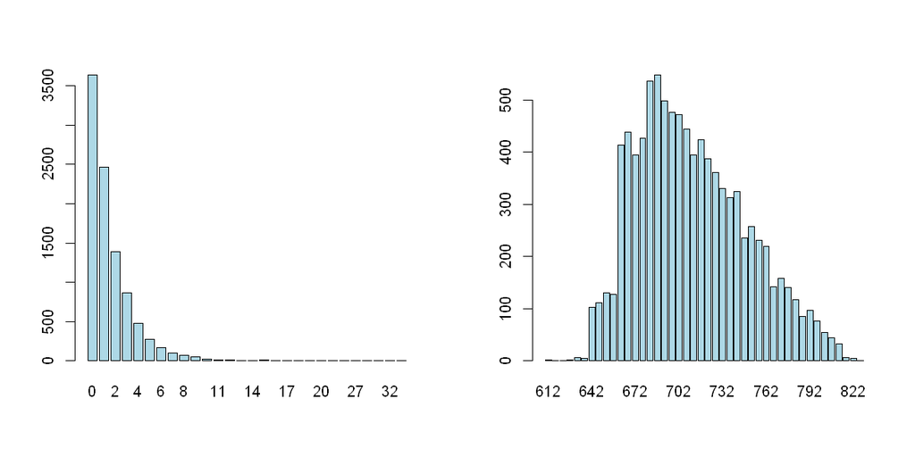

```r
options(repr.plot.width=10, repr.plot.height=5)
par(mfrow = c(1,2))
for (element in dist){
    barplot(element, col = "lightblue")
}
```

A gauche se trouve la distribution `inq.last.6mths` et à doite `fico`.

Malgré une certaine régularité dans la redondance de ces deux distribution, je concluerai que ces deux variables sont quantitatives.

## Traitement des données manquantes

```r
any(is.na(bank))
```

FALSE

Notre base de donnée ne contient aucune valeur manquante. Donc on peut continuer la suite de l'analyse.

```r
bank %>% dplyr::select(not.fully.paid) %>% table()
```

```
.
   0    1
8045 1533
```

## Analyse exploratoire des données

Dans cette partie, je vais fouiller les données dans le but de répondre aux questions suivantes:

```
 - Quelles sont les variables qui corrèlent entre elles.
- Notre variable est-elle expliquée est-elle biaisée? (Ce sera de répondre s'il y a autant de 0 que 1 dans les modalités)
```

Je ferai des visualisations pour comprendre les données.

```r
bank %>% head()
```

| credit.policy | purpose | int.rate | installment | log.annual.inc | dti | fico | days.with.cr.line | revol.bal | revol.util | inq.last.6mths | delinq.2yrs | pub.rec | not.fully.paid |
| --- | --- | --- | --- | --- | --- | --- | --- | --- | --- | --- | --- | --- | --- |
| 1 | debt_consolidation | 0.1189 | 829.10 | 11.35041 | 19.48 | 737 | 5639.958 | 28854 | 52.1 | 0 | 0 | 0 | 0 |
| 1 | credit_card | 0.1071 | 228.22 | 11.08214 | 14.29 | 707 | 2760.000 | 33623 | 76.7 | 0 | 0 | 0 | 0 |
| 1 | debt_consolidation | 0.1357 | 366.86 | 10.37349 | 11.63 | 682 | 4710.000 | 3511 | 25.6 | 1 | 0 | 0 | 0 |
| 1 | debt_consolidation | 0.1008 | 162.34 | 11.35041 | 8.10 | 712 | 2699.958 | 33667 | 73.2 | 1 | 0 | 0 | 0 |
| 1 | credit_card | 0.1426 | 102.92 | 11.29973 | 14.97 | 667 | 4066.000 | 4740 | 39.5 | 0 | 1 | 0 | 0 |
| 1 | credit_card | 0.0788 | 125.13 | 11.90497 | 16.98 | 727 | 6120.042 | 50807 | 51.0 | 0 | 0 | 0 | 0 |

### Correlations

La correlation se fait sur les variables numériques, donc nous devons enlever les variables facteurs.

```r
#install.packages("ggcorrplot")
```

```r
library(ggcorrplot)
```

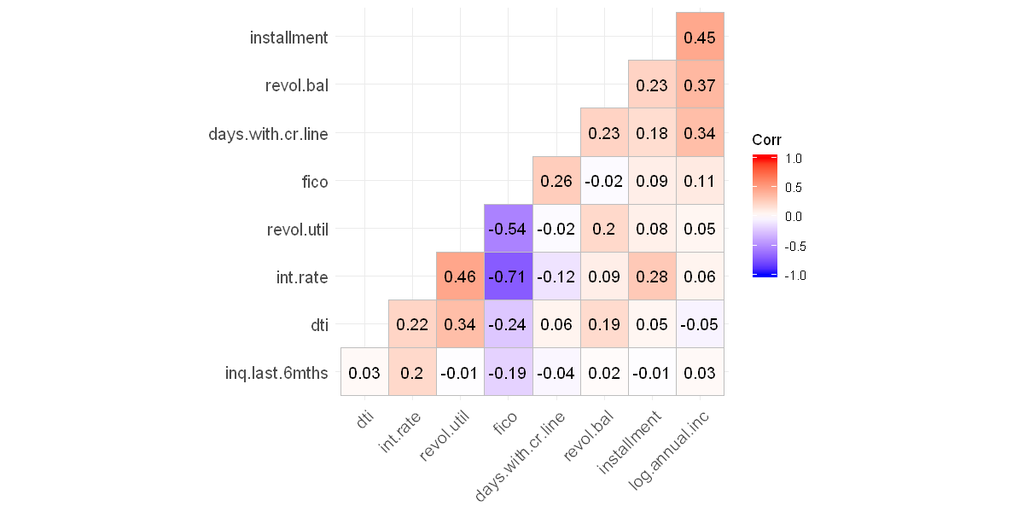

```r
bank[bank %>% sapply(is.numeric)] %>% cor() %>% ggcorrplot(hc.order = TRUE, type = "lower",
   lab = TRUE)
```

Globalement il y a une assez faible correlation entre les variables explicatives de notre base de donnée. Les plus fortes correlations concernent la variable `fico` qui corrèle négativement avec le taux d'intérêt `int.rate` **(-0.71)**

### Visualisation graphique

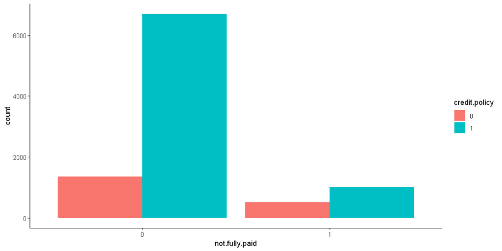

```r
# Bar
bank %>% ggplot(aes(x= not.fully.paid)) + geom_bar(aes(fill = credit.policy), position = "dodge") + theme_classic()
```

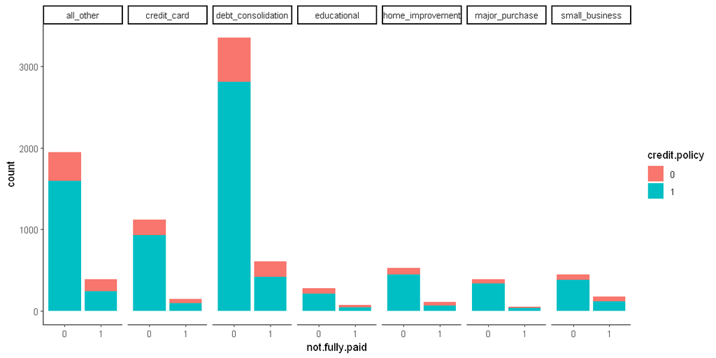

```r
bank %>% ggplot(aes(x= not.fully.paid)) + geom_bar(aes(fill = credit.policy)) +
facet_grid(~purpose) + theme_classic()
```

Ce graphique nous montre qu'une grande part des motifs d'endettement est la consolidation de dette `debt.consolidation`.

Notre variable explicative étant codée comme suit: 0, la personne a remboursé son emprunt, 1 elle ne l'a pas remboursé.

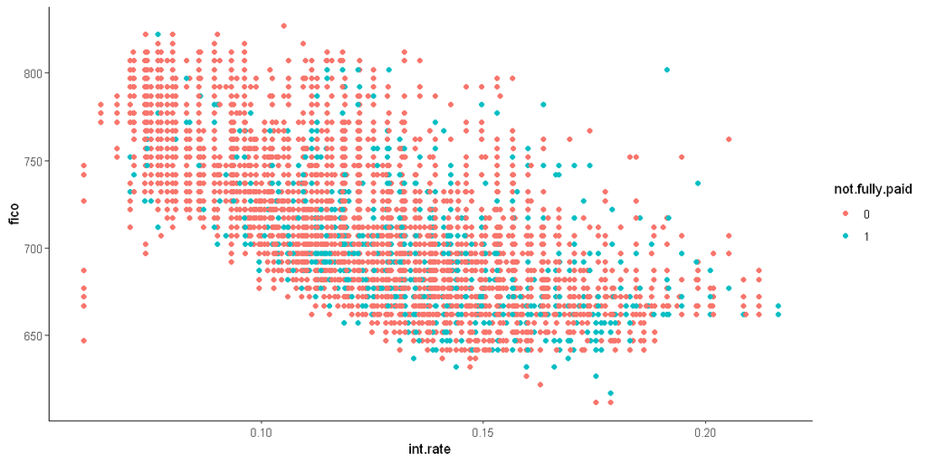

```r
bank %>% ggplot(aes(x= int.rate, y = fico)) + geom_point(aes(col = not.fully.paid)) + theme_classic()
```

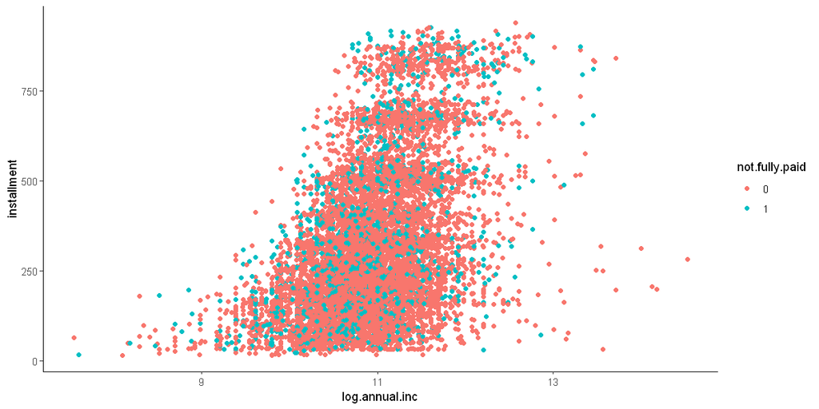

```r
bank %>% ggplot(aes(x= log.annual.inc, y = installment)) +
geom_point(aes(col = not.fully.paid)) + theme_classic()
```

Il n'y a pas vraiment de différence notable sur ce graphique entre les personnes qui ont payé leur dette et ceux ne l'ayant pas relativement au taux d'intérêt et au score fico.

## Régression logistique.

### Sélection des variables pertinentes

```r
library(MASS)
```

```r
library(leaps)
```

```r
modele<-glm((not.fully.paid~.),data=bank,family=binomial(logit))
result_aic <- stepAIC(modele,scope=list(lower=~1,upper=~.), data=bank,direction ="both")
```

```
Start:  AIC=7897.61
not.fully.paid ~ credit.policy + purpose + int.rate + installment +
    log.annual.inc + dti + fico + days.with.cr.line + revol.bal +
    revol.util + inq.last.6mths + delinq.2yrs + pub.rec

                    Df Deviance    AIC
- delinq.2yrs       10   7841.1 7885.1
- dti                1   7833.6 7895.6
- days.with.cr.line  1   7834.1 7896.1
- int.rate           1   7834.4 7896.4
<none>                   7833.6 7897.6
- revol.util         1   7837.2 7899.2
- revol.bal          1   7844.9 7906.9
- pub.rec            5   7854.1 7908.1
- credit.policy      1   7849.6 7911.6
- fico               1   7872.6 7934.6
- inq.last.6mths     1   7873.5 7935.5
- log.annual.inc     1   7880.8 7942.8
- installment        1   7881.4 7943.4
- purpose            6   7921.9 7973.9

Step:  AIC=7885.14
not.fully.paid ~ credit.policy + purpose + int.rate + installment +
    log.annual.inc + dti + fico + days.with.cr.line + revol.bal +
    revol.util + inq.last.6mths + pub.rec

                    Df Deviance    AIC
- dti                1   7841.1 7883.1
- days.with.cr.line  1   7841.4 7883.4
- int.rate           1   7841.9 7883.9
<none>                   7841.1 7885.1
- revol.util         1   7845.9 7887.9
- revol.bal          1   7853.0 7895.0
- pub.rec            5   7861.9 7895.9
+ delinq.2yrs       10   7833.6 7897.6
- credit.policy      1   7856.6 7898.6
- fico               1   7878.9 7920.9
- inq.last.6mths     1   7882.4 7924.4
- installment        1   7888.9 7930.9
- log.annual.inc     1   7889.6 7931.6
```

[output cut: 48 more lines]

```
                    Df Deviance    AIC
<none>                   7842.2 7880.2
+ int.rate           1   7841.4 7881.4
+ days.with.cr.line  1   7841.9 7881.9
+ dti                1   7842.2 7882.2
- revol.util         1   7848.0 7884.0
- revol.bal          1   7855.0 7891.0
- pub.rec            5   7863.7 7891.7
+ delinq.2yrs       10   7835.0 7893.0
- credit.policy      1   7857.9 7893.9
- inq.last.6mths     1   7884.6 7920.6
- log.annual.inc     1   7892.5 7928.5
- installment        1   7904.7 7940.7
- fico               1   7917.1 7953.1
- purpose            6   7941.8 7967.8
```

Le critère AIC nous suggère de construire un modèle avec 9 variables.

Notre modèle se présentera donc de cette manière :

```
not.fully.paid ~ credit.policy + purpose + installment + log.annual.inc +
    fico + revol.bal + revol.util + inq.last.6mths + pub.rec
```

```r
meilleur <- regsubsets(not.fully.paid~.,nbest=1,nvmax=14,method="exhaustive",data=bank)
```

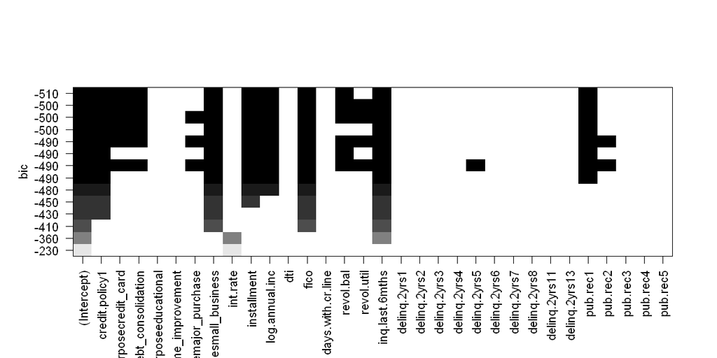

```r
plot(meilleur)
```

### Régression logistique

```r
modele_logistique <- glm((not.fully.paid~credit.policy + purpose + installment + log.annual.inc +
    fico + revol.bal + revol.util + inq.last.6mths + pub.rec),data=bank,family=binomial(logit))
```

```r
library(broom)
```

```r
summary(modele_logistique)
```

```
Call:
glm(formula = (not.fully.paid ~ credit.policy + purpose + installment +
    log.annual.inc + fico + revol.bal + revol.util + inq.last.6mths +
    pub.rec), family = binomial(logit), data = bank)

Deviance Residuals:
    Min       1Q   Median       3Q      Max
-2.3199  -0.6180  -0.4955  -0.3656   2.6454

Coefficients:
                            Estimate Std. Error z value Pr(>|z|)
(Intercept)                8.782e+00  9.437e-01   9.306  < 2e-16 ***
credit.policy1            -3.363e-01  8.420e-02  -3.995 6.48e-05 ***
purposecredit_card        -5.256e-01  1.086e-01  -4.841 1.29e-06 ***
purposedebt_consolidation -3.441e-01  7.676e-02  -4.482 7.39e-06 ***
purposeeducational         6.772e-02  1.520e-01   0.445 0.655988
purposehome_improvement    1.043e-01  1.262e-01   0.826 0.408701
purposemajor_purchase     -3.374e-01  1.663e-01  -2.030 0.042391 *
purposesmall_business      5.594e-01  1.139e-01   4.913 8.95e-07 ***
installment                1.277e-03  1.606e-04   7.955 1.80e-15 ***
log.annual.inc            -4.068e-01  5.786e-02  -7.030 2.07e-12 ***
fico                      -9.068e-03  1.060e-03  -8.559  < 2e-16 ***
revol.bal                  3.183e-06  9.300e-07   3.422 0.000621 ***
revol.util                 2.931e-03  1.222e-03   2.397 0.016519 *
inq.last.6mths             8.774e-02  1.373e-02   6.392 1.63e-10 ***
pub.rec1                   4.594e-01  1.092e-01   4.208 2.57e-05 ***
pub.rec2                  -8.889e-01  7.588e-01  -1.171 0.241469
pub.rec3                  -1.183e+01  2.305e+02  -0.051 0.959060
pub.rec4                  -1.183e+01  5.354e+02  -0.022 0.982371
pub.rec5                  -1.276e+01  5.354e+02  -0.024 0.980991
---
Signif. codes:  0 '***' 0.001 '**' 0.01 '*' 0.05 '.' 0.1 ' ' 1

(Dispersion parameter for binomial family taken to be 1)

    Null deviance: 8424.0  on 9577  degrees of freedom
Residual deviance: 7842.2  on 9559  degrees of freedom
AIC: 7880.2

Number of Fisher Scoring iterations: 12
```

Les coefficients qui ont une p-value <0.05 sont significatifs, c'est ceux qui ont des étoiles *

Nous allons maintenant calculer les indicateurs qui vont avec les résultats de la régression logistique.

**Sigificativité globale** : équivalent du test de Fisher

```r
chi2<-2*(modele_logistique$null.deviance-modele_logistique$deviance)
ddl<-modele_logistique$df.null-modele_logistique$df.residual
pvalue<-pchisq(chi2,ddl,lower.tail=F)
print(pvalue)
```

```
[1] 6.901129e-236
```

[output not shown]

*R² de MacFadden

```r
R2_Mc_Fadden<-1-(modele_logistique$deviance/modele_logistique$null.deviance)
print(paste("le R² de MacFadden est de", round(R2_Mc_Fadden,2), "ce qui veut dire que le modèle explique environ",
100*round(R2_Mc_Fadden,2), "%", " de la variabilité de la variable expliquée"))
```

```
[1] "le R² de MacFadden est de 0.07 ce qui veut dire que le modèle explique environ 7 %  de la variabilité de la variable expliquée"
```

**Prédiction et indicateurs**

```r
pred.proba<-predict(modele_logistique,type="response")
pred.moda<-factor(ifelse(pred.proba>0.5,"1","0"))
```

```r
pred.moda %>% table()
```

```
.
   0    1
9483   95
```

Il semblerait que la modèle a pour la plupart, classé les observé comme 0 car comme nous l'avons vu plus haut, la plupart des individus des observation avait 0 en `not.fully.paid`.

La matrice de confusion suivante nous donne une indication de la performance du modèle; en bref ce modèle n'est pas du tout performant, voilà pourquoi je vais essayer un autre modèle.

```r
table(bank[,"not.fully.paid"], pred.moda)
```

```
   pred.moda
       0    1
  0 7999   46
  1 1484   49
```